# Tie Strength, Role Relations, and Social Support in Ego Networks

Decoupling Relational Frames with Multilevel Longitudinal Panel Data

David Hachen

University of Notre Dame

Omar Lizardo

University of California, Los Angeles

2026-09-01

# Introduction & Theoretical Foundations

## Properties of Social Ties

- **Dyadic ties** (edges, links) are the elemental building blocks of networks.
- Most network research prioritizes **network-level topology**:
  - Density, modularity, centrality, clustering, small-world architecture.
- Yet ties themselves possess vital **internal relational properties**:
  - Strength, multiplexity, duration, role content, valence, and resource flows.
- **The Core Problem**:
  - How do interpersonal ties organize and activate specialized forms of functional social support within personal communities?

**Network vs. Dyadic Level**

Moving beyond overall structural topology requires examining the **micro-architecture of dyadic bonds** where interpersonal support actually transpires.

## Typologies of Social Ties

How many distinct types of social ties exist?

Following the influential taxonomy of **Borgatti et al. (2009)**, interpersonal ties fall into two broad structural modes:

### 1. Continuous States

- **Similarities**: Shared physical locations, group co-memberships, demographic homophily.
- **Role Relations**: Kinship, friendship, romantic partnerships, coworker or acquaintance ties.
- **Sentiments**: Affective closeness, liking, trust, psychological intimacy.

### 2. Discrete Events

- **Interactions**: Behavioral contact, communication frequency, talk, shared activities.
- **Flows & Exchanges**: Information transmission, social support, financial aid, personal advice.

**The Fundamental Question**

What is the structural and empirical relationship among these distinct relational dimensions?

## Tie Properties: The Concept of “Tie Strength”

In his seminal formulation, **Granovetter (1973: 1361)** defined tie strength as:

$$\text{Tie Strength} = f(\text{Time}, \text{Emotional Intensity}, \text{Intimacy}, \text{Reciprocal Services})$$

- Tie strength was conceptualized as a **multidimensional bundle**:
  - Amount of time spent together (frequency and duration)
  - Emotional intensity
  - Intimacy (mutual confiding)
  - Reciprocal services (social support provision)
- **The Classical Conflation**:
  - Subsequent scholarship routinely collapsed these distinct domains into a **single linear continuum** from “weak” to “strong.”

## Measuring Tie Strength: Pervasive Pitfalls

Pervasive conceptual and empirical conflations have hindered network research:

### 1. Conflating Roles & Strength

- Assuming that family and friends are “strong ties” by definition, while coworkers and acquaintances are inherently “weak ties” (Lin 2001; Wellman and Wortley 1990).
- Obscures vital variation: emotionally distant kin vs. intensely close casual associates.

### 2. Conflating Contact & Intimacy

- Daily contact is often driven by shared organizational foci (dormitories, workplaces) rather than mutual confiding (Feld 1982).

### 3. Assuming Generalized Support

- Assuming that “strong ties” universally provide all forms of assistance, whereas “weak ties” serve only as informational bridges.

## Marsden and Campbell’s (1984) Foundational Model

**Marsden and Campbell (1984)** introduced a crucial methodological clarification:

### Indicators of Tie Strength

- *Internal properties constituting the bond itself*:
  - **Emotional closeness** (primary, most valid indicator)
  - **Contact frequency** (contaminated by institutional foci)
  - **Duration** (temporal relational investment)

### Predictors of Tie Strength

- *Structural and relational contexts generating ties*:
  - **Social role categories** (kin, friend, acquaintance)
  - **Sociodemographic similarity** (homophily)
  - **Shared affiliations** (dorm, workplace, classroom)

**Methodological Principle**

The relationship between indicators and predictors of tie strength is an **empirical question**, not a definitional certainty.

## Theoretical Advancement: Decoupling Relational Frames

Building on Marsden and Campbell (1984), **Lizardo (2024)** develops a frame-analytic model that systematically decouples **six autonomous relational dimensions**:

1. **Sentiment Frames**: Subjective emotional closeness, affective intimacy.
2. **Interaction Frames**: Observable contact frequency, behavioral activation.
3. **Relational History**: Relationship duration across the life course.
4. **Cognitive Salience**: Retrieval accessibility during free-recall name generation.
5. **Role Frames**: Categorical institutional identities (friend, kin, partner, acquaintance).
6. **Exchange Frames**: Functional transmission of tangible resources (support).

**Analytical Goal**

Empirically examine how these distinct frames independently sort dyadic ties into specialized support regimes without definitional circularity.

## Research Questions

### RQ1: Interdependence of Dimensions

- How do affective closeness, contact frequency, cognitive salience, and duration relate to one another within personal communities?

### RQ2: Structural Role Differentiation

- How do institutional role relations (family, friend, romantic partner, acquaintance) sort specific tie strength dimensions?

### RQ3: Prediction of Support Regimes

- Do tie strength indicators and role relations independently predict membership in distinct configurations of functional social support?
- Does support organize along a single hierarchy, or through a specialized functional division of labor?

# Data, Design, and Measurement

## The NetHealth Study

- **Longitudinal Panel Investigation**:
  - Tracked an undergraduate cohort at the **University of Notre Dame** (Class of 2019).
  - Matriculation in August 2015 through graduation in May 2019.
- **Scope & Objectives**:
  - Investigated the reciprocal co-evolution of social networks, health behaviors (physical activity, sleep, stress), and academic trajectories.
- **Ego-Network Survey Battery**:
  - Administered online via Qualtrics at the beginning and end of academic semesters.

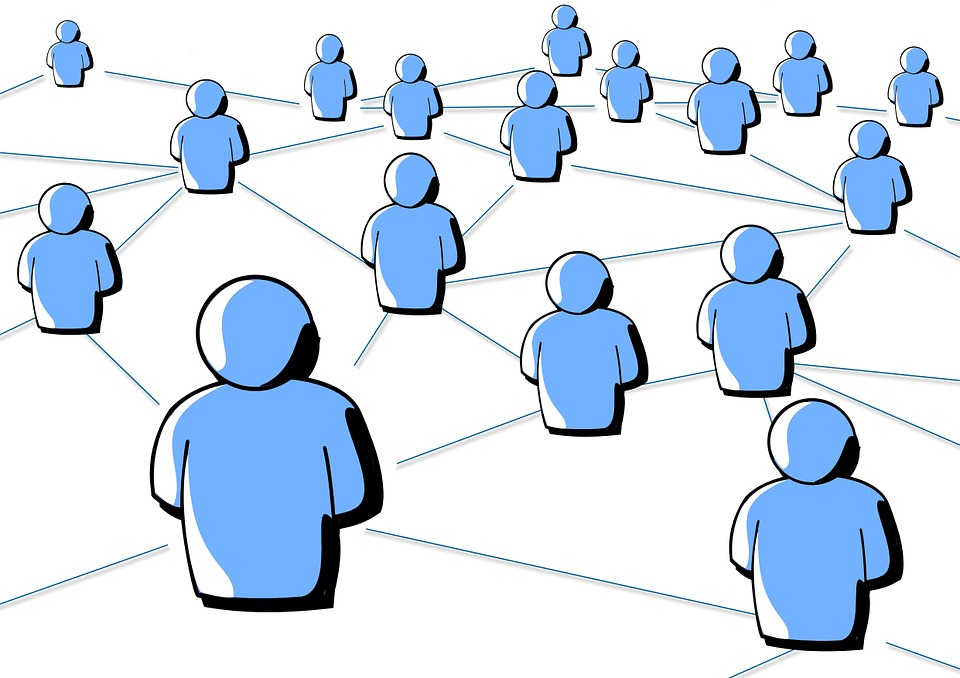

## Ego Network Panel Design

- **Panel Administration**:
  - 8 survey waves conducted between Fall 2015 and Spring 2019.
  - Dedicated **Social Support Module** administered across 6 waves:
    - **Waves 2, 3, 4, 5, 7, and 8**.
- **Name Generator Prompt**:
  - *“We would like to know who you consider to be in your social network. In the spaces below, list up to 20 people with whom you spend time communicating or interacting.”*
  - Allowed respondents to retain up to 5 alters from preceding waves (up to 25 named alters per wave).
- **Analytical Sample Size**:
  - **$N = 22,739$** dyadic tie observations nested within **$N = 626$** unique respondents across the six support-administered waves.
  - **$N = 22,737$** ties across **$N = 581$** egos with complete covariate data for multilevel modeling.

## Measurement: Tie Strength Indicators

### Affective Closeness

- *Subjective emotional intimacy*:
  - Distant
  - Less Close
  - **Close** *(Reference)*
  - Especially Close

### Interaction Frequency

- *Behavioral contact rate*:
  - Less than Monthly
  - Monthly
  - **Weekly** *(Reference)*
  - Daily

### Cognitive Salience

- *Retrieval rank in name generation*:
  - Top 5 (Highly salient)
  - **Middle 10** *(Reference)*
  - Bottom 5

### Relationship Duration

- *Relational longevity*:
  - $< 2$ Years
  - **2–4 Years** *(Reference)*
  - 5–10 Years
  - $> 10$ Years

## Measurement: Roles, Context, and Support Battery

### Social Role Relations

- **Friend** *(Reference category)*
- Family
- Romantic Partner
- Acquaintance
- Other Role (neighbor, coworker, advisor)

### Contextual & Demographic Controls

- **Ego Gender**: Women *(Ref)* vs. Men
- **Same Dormitory**: Shared residence hall
- **Roommate**: Direct shared room

### The 4 Support Items

Respondents indicated whether each named alter provided four distinct forms of assistance:

1. **Companionship**:
   - *Hanging out when feeling like company*
2. **Advice**:
   - *Advice when dealing with a life problem*
3. **Comfort**:
   - *Comforting when something bad happened*
4. **Financial Assistance**:
   - *Gone to when in financial need*

# Analytical Strategy: Two-Stage Modeling Framework

## Methodological Challenges in Network Support Research

Evaluating social support in personal networks poses three key analytical challenges:

### 1. Complex Multidimensionality

- Support exchanges are multiplex across distinct domains (social, emotional, informational, material).
- Imposing manual heuristic groupings obscures the **natural, emergent configurations** of support that exist in personal communities.

### 2. Dyadic Clustering

- Ties are nested within respondents ($N = 22,737$ ties within $J = 581$ egos).
- Violating independence deflates standard errors and conflates within-ego from between-ego variation.

### 3. Sparse Cells & Quasi-Separation

- Specialized support types cross-classified with specific roles produce extreme sparsity (e.g., only 1 acquaintance in instrumental kin support).
- Under simultaneous multinomial estimators, sparse cells induce **quasi-complete separation**, leading to non-convergence and unstable covariance matrices.
- **Solution**: Separate binary GLMMs allow robust convergence without collapsing granular categories.

## The Two-Stage Analytical Architecture

To address these challenges, we implement a **unified two-stage empirical framework**:

### Stage 1: Inductive LCA

- **Latent Class Analysis (`poLCA`)**:
  - Unsupervised finite mixture model across the 4 binary Qualtrics support items.
  - Identifies discrete, latent support configurations directly from response patterns ($K = 2 \dots 5$).
  - Evaluates goodness-of-fit via AIC, BIC, and classification entropy.

### Stage 2: Confirmatory Multilevel GLMMs

- **Hierarchical Logistic Mixed Models (`lme4`)**:
  - Predicts membership in each latent configuration directly:
    $$\text{logit}(P(Y_{ij}=k)) = \beta_{0k} + \mathbf{X}_{ij}\boldsymbol{\beta}_k + u_{jk}$$
  - Ego random intercepts ($u_{jk} \sim \mathcal{N}(0, \sigma_{uk}^2)$) account for respondent-level clustering.
  - Simultaneously estimates all 18 predictors.

# Stage 1: Latent Support Configurations

## Stage 1: LCA Model Selection

Model fit statistics across $K = 2 \dots 5$ latent classes ($N = 22,739$ ties):

| Latent Classes | Log-Likelihood | Par | AIC | BIC | Entropy |
| --- | --- | --- | --- | --- | --- |
| 2 Classes | -42,348.5 | 9 | 84,714.9 | 84,787.2 | 0.760 |
| 3 Classes | -41,670.9 | 14 | 83,369.8 | 83,482.2 | 0.858 |
| **4 Classes** | **-41,626.6** | **19** | **83,291.2** | **83,443.8** | **0.766** |
| 5 Classes | -41,626.6 | 24 | 83,301.2 | 83,493.9 | 0.722 |

**Optimal Solution: 4 Classes**

The **4-Class solution** minimizes both AIC (83,291.2) and BIC (83,443.8) while maintaining solid classification entropy (0.766). Adding a 5th class yields no improvement in log-likelihood ($\Delta\text{LL} = 0$) and penalizes model parsimony.

## Latent Class Support Profiles (Figure 1)

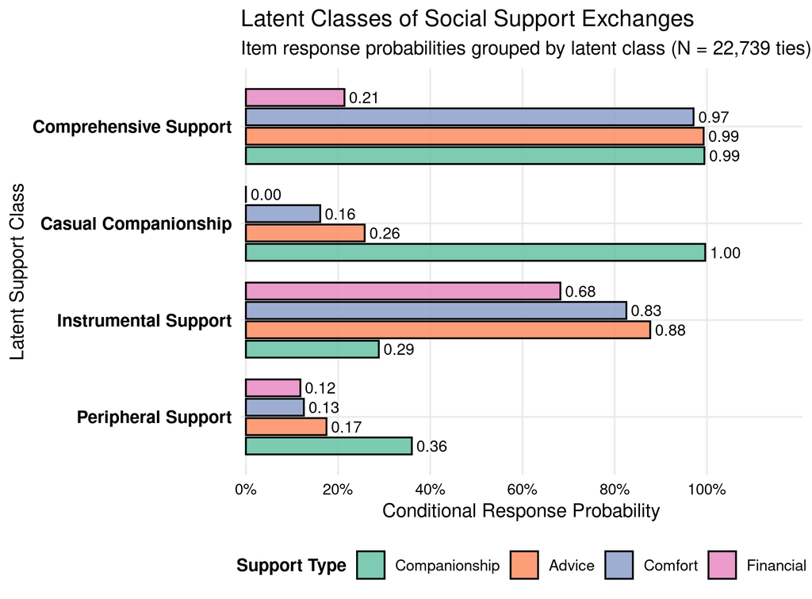

The LCA reveals marked **functional specialization** in personal communities:

### 1. Casual Companionship (45.8%)

- **Companionship = 1.00**; Financial = 0.00.
- Low Advice (0.26) and Comfort (0.16).
- *Everyday collegiate socializing without deep confiding or material exchange.*

### 2. Comprehensive Support (41.5%)

- **Companionship = 0.99, Advice = 0.99, Comfort = 0.97**.
- Moderate Financial (0.21).
- *Multiplex core confidants providing holistic expressive and practical backing.*

### 3. Instrumental Support (4.3%)

- **Financial = 0.68, Advice = 0.88, Comfort = 0.83**.
- **Low Companionship = 0.29**.
- *Specialized material and guidance anchors; kin-based assistance without daily socializing.*

## Cross-Classifying Roles and Support Regimes

Distribution of Latent Support Classes across Roles and Closeness ($N = 22,739$):

| Dimension & Category | Casual Companionship | Comprehensive Support | Instrumental Support | Peripheral Support |
| --- | --- | --- | --- | --- |
| **Social Role Relation** |  |  |  |  |
| Friend | **53.8%** | **40.5%** | 1.0% | 4.8% |
| Family | 15.3% | **58.3%** | **17.8%** | 8.6% |
| Romantic Partner | 14.8% | **81.7%** | 1.5% | 1.9% |
| Acquaintance | 44.8% | 5.4% | 0.5% | **49.3%** |
| Other Role | 50.5% | 13.8% | 2.2% | **33.5%** |
| **Emotional Closeness** |  |  |  |  |
| Distant | 43.5% | 16.5% | 3.5% | **36.5%** |
| Less Close | **66.5%** | 5.0% | 1.6% | **26.9%** |
| Close | **69.3%** | 19.3% | 2.4% | 9.0% |
| Especially Close | 29.0% | **61.7%** | 6.2% | 3.1% |

# Stage 2: Multilevel GLMM Results

## Multilevel GLMMs: Partitioning Variance

Before examining predictors, do personal networks exhibit meaningful respondent clustering?

$$\text{Latent ICC} = \frac{\sigma_u^2}{\sigma_u^2 + \pi^2/3}$$

### Ego Random Intercept Variance

- **Casual Companionship**:
  - $\sigma_u^2 = 1.082 \implies \mathbf{\text{ICC} = 0.248}$
- **Comprehensive Support**:
  - $\sigma_u^2 = 1.457 \implies \mathbf{\text{ICC} = 0.307}$

### Substantial Clustering

- **Instrumental Support**:
  - $\sigma_u^2 = 1.821 \implies \mathbf{\text{ICC} = 0.356}$
- **Peripheral Support**:
  - $\sigma_u^2 = 2.016 \implies \mathbf{\text{ICC} = 0.380}$

**Substantive Meaning**

Between 25% and 38% of variance in tie support assignment reflects **ego-level sociability and reporting thresholds**—confirming that accounting for dyadic clustering with random ego intercepts is indispensable.

## Comprehensive Multilevel Forest Plot (Figure 2)

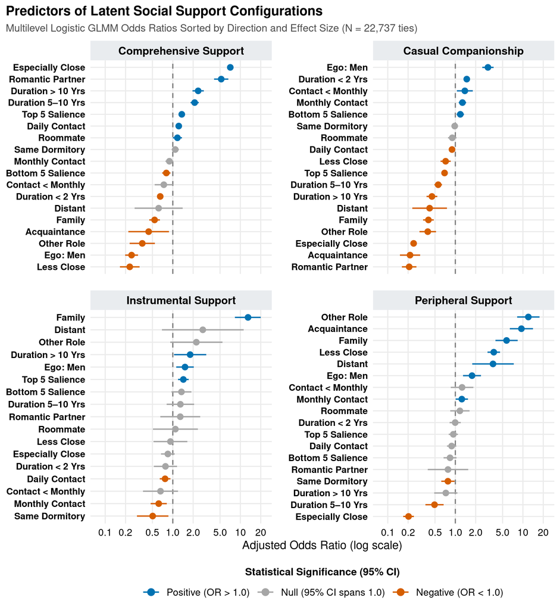

## Predicting Comprehensive Support

Who provides multi-domain, holistic support?

- **Emotional Closeness**:
  - Especially Close: $\mathbf{\text{OR} = 7.09}$ ($p < 0.001$).
  - Less Close: $\text{OR} = 0.23$ (77% lower odds).
- **Relational Longevity**:
  - $> 10$ Years: $\mathbf{\text{OR} = 2.37}$ ($p < 0.001$).
  - 5–10 Years: $\mathbf{\text{OR} = 2.10}$ ($p < 0.001$).
- **Cognitive Salience**:
  - Top 5 in Name Generator: $\mathbf{\text{OR} = 1.36}$ ($p < 0.001$).
- **Role Relations**:
  - Romantic Partners: $\mathbf{\text{OR} = 5.20}$ ($p < 0.001$).
- **Gender Disparity**:
  - Men: $\mathbf{\text{OR} = 0.25}$ (75% lower odds than women).

**Substantive Engine**

Comprehensive support requires a confluence of **affective intimacy, relational history, and cognitive salience**. Men maintain substantially fewer comprehensive ties.

## Predicting Casual Companionship

What governs everyday sociability without confiding?

- **Governed by Peer Friendships**:
  - Family: $\text{OR} = 0.40$ ($p < 0.001$).
  - Romantic Partners: $\text{OR} = 0.21$ ($p < 0.001$).
  - Acquaintances: $\text{OR} = 0.21$ ($p < 0.001$).
- **The Closeness Inversion**:
  - Especially Close: $\mathbf{\text{OR} = 0.24}$ ($p < 0.001$).
  - *Deep intimacy elevates ties out of casual companionship and into comprehensive backing.*
- **Cognitive Salience**:
  - Top 5 alters: $\text{OR} = 0.69$ ($p < 0.001$).
  - *Confirms that cognitive retrieval prioritizes confidants over recreational peers.*
- **Gender Dynamics**:
  - Men: $\mathbf{\text{OR} = 3.04}$ (threefold higher odds).

**Men’s Network Orientation**

Men’s personal communities are disproportionately weighted toward **activity-based socializing** rather than expressive confiding.

## Predicting Instrumental Support

What governs material aid and practical advice?

- **Kinship Role Dominance**:
  - Family ties exhibit a dramatic thirteen-fold elevation: $\mathbf{\text{OR} = 12.98}$ ($95\%\text{ CI } [8.29, 20.30]$).
  - Acquaintances virtually never provide instrumental aid ($\text{OR} < 0.01$).
- **The Spatial Dispersion Paradox**:
  - Daily Contact Frequency: $\mathbf{\text{OR} = 0.77}$ ($p = 0.005$).
  - *Daily interaction is negatively associated with instrumental aid, reflecting collegiate geographic distance from parental households.*
- **Long-Term Anchoring**:
  - Duration $> 10$ Years: $\text{OR} = 1.81$ ($p = 0.035$).
  - Top 5 Salience: $\text{OR} = 1.43$ ($p < 0.001$).

**Kinship Obligations**

Material backing is regulated by **institutional kinship roles**, remaining active despite low everyday interaction.

## Predicting Peripheral Support

What characterizes marginal, low-support ties?

- **Affective Distancing**:
  - Less Close: $\mathbf{\text{OR} = 3.71}$ ($p < 0.001$).
  - Distant: $\mathbf{\text{OR} = 3.61}$ ($p < 0.001$).
  - Especially Close: $\text{OR} = 0.20$ ($p < 0.001$).
- **Role Stratification**:
  - Acquaintances: $\mathbf{\text{OR} = 9.50}$ ($p < 0.001$).
  - Other Roles: $\mathbf{\text{OR} = 12.03}$ ($p < 0.001$).
- **Relational History as a Protective Buffer**:
  - 5–10 Years Duration: $\mathbf{\text{OR} = 0.49}$ ($p < 0.001$).
  - Longstanding ties are protected from peripheral marginalization.

**Structural Relegation**

Peripheral ties combine **weak sentiments with non-intimate roles**, forming low-stakes secondary circles.

## Organizational Context & Gender Summaries

### The Gendered Division of Labor

- **Women**:
  - Prioritize multiplex, emotionally close ties providing expressive confiding and advice (**Comprehensive Support**).
- **Men**:
  - Exhibit 3x higher odds of maintaining **Casual Companionship** ties.
  - Personal networks weighted toward recreational, low-confiding sociability.

# Discussion & Theoretical Implications

## Discussion: Summary of Key Findings

### 1. Relational Cartography

- Rather than an undifferentiated continuum from “weak” to “strong,” personal communities organize into **four functionally specialized support configurations**.

### 2. Decoupling Relational Frames

- Validates **Marsden and Campbell (1984)** and **Lizardo (2024)**:
  - Sentiments, interaction rates, cognitive salience, duration, and roles operate as distinct, non-redundant relational attributes.

### 3. Institutional Boundaries

- Kinship roles govern material survival and financial aid.
- Friendship governs everyday sociability and peer companionship.
- Affective intimacy is an indispensable prerequisite for expressive confiding.
- Cognitive prominence and relational history preserve access across physical distance.

## Limitations and Future Directions

### 1. Measurement & Intensity

- **Binary Incidence**:
  - Survey items record occurrence (Yes/No), not transaction volume, dollar amounts, or affective depth.
- **Future Agenda**:
  - Multi-item scales of emotional intensity.
  - Experience Sampling Methods (ESM) / Ecological Momentary Assessments (EMA) tracking real-time activation.

### 2. Causal Inference & Scope

- **Reciprocal Feedback Loops**:
  - Does closeness cause support, or does support deepen intimacy?
  - Need cross-lagged panel models and continuous-time event history setups.
- **Institutional Context**:
  - Collegiate life-course transition (dorm density, parental distance).
  - Generalizing to older adults, non-collegiate populations, and non-Western kinship systems.

## Theoretical Implications: Beyond Unidimensional Tie Strength

- **Revisiting Classical Social Capital**:
  - Classical models (Granovetter 1973; Coleman 1988; Lin 2001) often assumed strong ties uniformly provide all assistance.
- **“Strong Ties” Are Not All Created Equal**:
  - High contact frequency does not guarantee confiding.
  - Emotional closeness does not ensure financial assistance.
  - Kinship functions as an enduring anchor net of daily activation.
- **The Value of Non-Intimate Ties**:
  - As **Small (2017)** notes, casual companions and acquaintances serve vital specialized functions, providing low-stakes sociability without emotional vulnerability.

**Core Theoretical Shift**

Social capital is not a unidimensional scalar quantity; it is a **differentiated matrix of relational frames**.

## Theoretical Implications: Diversified Relational Portfolios

- **Personal Communities as Relational Portfolios**:
  - Well-being and social resilience do not depend on maximizing an undifferentiated volume of “strong” ties.
  - Resilience requires a **balanced, diversified portfolio**:
    - Family ties for durable material backing during crises.
    - Peer friends for everyday companionship and routine sociability.
    - Core confidants for emotional comfort and personal guidance.
- **Independent Structural Anchors**:
  - **Cognitive salience** and **relational duration** preserve access to resources across geographic distance and life-course transitions.

**Take-Home Message**

Decoupling relational frames provides the structural foundation needed to model how personal networks sustain well-being across the life course.

## Concluding Summary

### Conceptual Contributions

- **Decoupled Relational Frames**:
  - Differentiates sentiment, interaction, history, salience, roles, and functional support.
- **Specialized Division of Labor**:
  - Replaces the unidimensional weak/strong continuum with discrete, specialized relational regimes.
- **Relational Portfolios**:
  - Re-theorizes social capital as maintaining a diversified matrix of ties across distinct life domains.

### Methodological & Empirical Advances

- **Unified Two-Stage Framework**:
  - Combines inductive LCA with confirmatory multilevel GLMMs.
- **Ego-Clustering Accounting**:
  - Explicitly partitions variance via random ego intercepts ($\text{ICC} = 0.25–0.38$).
- **Comprehensive 18-Predictor Mapping**:
  - Simultaneously estimates tie strength, role relations, and contexts without category collapsing.

### Thank You! Questions & Discussion

**David Hachen** (`dhachen@nd.edu`) & **Omar Lizardo** (`olizardo@soc.ucla.edu`)